# Final Report

Lee

2019-12-13

```r
library(tidyverse)
```

# 1 Import Data

```r
df <- read.csv('./preprocessed.csv') %>% select(-X) %>% filter()
temp_corr <- colnames(df)
```

관광설문조사 데이터와 트립어드바이저 리뷰를 통해 얻어낸 LDA results를 join시키자.

```r
lda_results <- read.csv('LDA_results.csv') %>% select(-X)
df <- left_join(df, lda_results, by='category')
prev_nrow <- nrow(df)
```

보다 정확한 추천을 위해서 토픽의 highest_ratio가 0.8이 안되는 애매한 토픽의 관광지는 제거하자.

```r
THRESHOLD_TOPIC = 0.8
df %>% filter(highest_ratio<THRESHOLD_TOPIC) %>% distinct(만족방문지)
```

```
##                              만족방문지
## 1                                월미도
## 2                         용궁사 / 기장
## 3                                코엑스
## 4                          감천문화마을
## 5  설악산, 속초, 양양 (설악산 국립공원)
## 6   동성로 (근대골목, 김광석길, 약령시)
## 7                       용두산 / 자갈치
## 8                                태종대
## 9                            한국민속촌
## 10                      전주 (한옥마을)
## 11             거제 (바람의 언덕, 외도)
## 12        통영 (한려수도 조망케이블 카)
```

```r
df <- df %>% filter(highest_ratio>=THRESHOLD_TOPIC)
now <- nrow(df)
print(paste(prev_nrow, '에서', prev_nrow-now, '개의 설문조사 제거'))
```

```
## [1] "11795 에서 1084 개의 설문조사 제거"
```

```r
# 이는 모델에 들어갈 변수이고 범주형으로 변환해주자.
df$highest_topic <- factor(df$highest_topic)
```

# 2 Modeling - Intro

모델을 와닿게 설명을 하면, *가장 높은 토픽(1, 2, 3, 4)이 뭔지만 알려주면 (t1, t2, t3, t4)를 다 찾아서 당신이 좋아할만한 3가지 여행지를 추천해드립니다!* 이다.

그리고 이를 위해, 선형회귀 모형 4개를 이용하여 t1~t4까지 채울 예정이다.

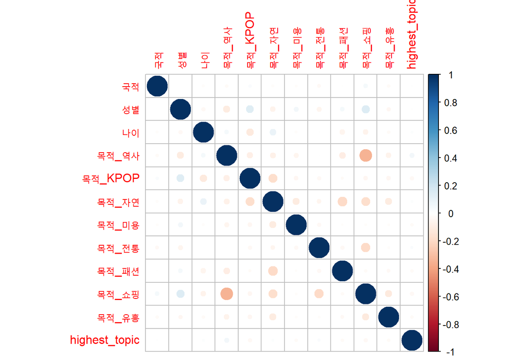

```r
library(corrplot)
temp_corr <- c(temp_corr, 'highest_topic') # highest_topic도 모델에 포함하기로 결정
test_corr <- df %>% select(temp_corr) %>% select(-category, -만족방문지)
test_corr <- as.data.frame(lapply(test_corr, as.integer))
test_corr %>% cor %>% corrplot
```

우리는 다중선형회귀 모형을 사용할 예정인 만큼 상관계수를 한번 보도록 하자.

각 변수들의 상관계수가 작은 편이기 때문에 **다변수 회귀 계수 해석**이 **안전**하다.

Analysis2에서는 부족한 설명력을 보완하기 위해 교호작용을 넣었고, 이로인해 설명변수가 134개로 늘어나 복잡해졌기에 인터랙션 텀에 대한 계수는 거의 해석하지 않겠다.

앞으로 자주 언급하게 될 토픽에 대해서 표기를 정리하고 가겠다.

> 토픽 1 : (도시 - 조용한) 토픽 2 : (도시 - 번화가의) 토픽 3 : (역사 - 조용한) 토픽 4 : (자연 - 조용한)

## 2.1 토픽 ~ 가장 높은 토픽, **방문고려요인**

```r
library("rlang")
test1 <- df %>% select(starts_with('목적_'), highest_topic)

temp <- colnames(test1)
temp_loc <- which(!grepl('highest_topic', temp))
temp2 <- temp[temp_loc]
temp3 <- paste(temp2, collapse = paste(' *', 'highest_topic', '+ '))

test1_model1 <- as.formula(paste('topic1 ~', temp3, '* highest_topic'))
test1_model2 <- as.formula(paste('topic2 ~', temp3, '* highest_topic'))
test1_model3 <- as.formula(paste('topic3 ~', temp3, '* highest_topic'))
test1_model4 <- as.formula(paste('topic4 ~', temp3, '* highest_topic'))
# "df$topic1 ~ 목적_역사 * highest_topic + 목적_KPOP * highest_topic + 목적_자연 * highest_topic + 목적_미용 * highest_topic + 목적_전통 * highest_topic + 목적_패션 * highest_topic + 목적_쇼핑 * highest_topic + 목적_유흥 * highest_topic"


model1 <- eval(expr(lm(!!test1_model1, data=df)))
model2 <- eval(expr(lm(!!test1_model2, data=df)))
model3 <- eval(expr(lm(!!test1_model3, data=df)))
model4 <- eval(expr(lm(!!test1_model4, data=df)))
```

간단하게 회귀 계수에 대해서 짚고 넘어가자. 이는 토픽 1을 예측하는 모형의 기울기 계수이다.

당연히 가장 높은게 2 혹은 3 혹은 4임을 아는 상황에선, 토픽1을 예측할 때 낮게 배팅할 수 밖에 없음을 의미한다.

```r
broom::tidy(model1)[3:5, c('term', 'estimate')]
```

```
## # A tibble: 3 x 2
##   term           estimate
##   <chr>             <dbl>
## 1 highest_topic2   -0.948
## 2 highest_topic3   -0.954
## 3 highest_topic4   -0.956
```

```r
significant11 <- broom::tidy(model1) %>%
    filter(abs(statistic) > 1.9) # 유의한 것 중에

g1 <- significant11[nchar(significant11$term) < 10, ] %>% # 목적 변수만
    ggplot(aes(factor(term), estimate)) +
    geom_hline(yintercept = 0, size=3) +
    geom_bar(stat='identity') +
    labs(x='목적', title='조용한도시 ~ 방문고려요인') +
    theme(plot.title = element_text(face = "bold", size = 15, hjust=0.5),
          axis.ticks = element_blank(),
          axis.text.x = element_text(angle = -90, vjust = 1, hjust = 0),
          panel.grid.minor = element_blank())
```

```r
significant21 <- broom::tidy(model2) %>%
    filter(abs(statistic) > 1.9) # 유의한 것 중에


g2 <- significant21[nchar(significant21$term) < 10, ] %>% # 목적 변수만
    ggplot(aes(factor(term), estimate)) +
    geom_hline(yintercept = 0, size=3) +
    geom_bar(stat='identity') +
    labs(x='목적', title='번화가도시 ~ 방문고려요인') +
    theme(plot.title = element_text(face = "bold", size = 15, hjust=0.5),
          axis.ticks = element_blank(),
          axis.text.x = element_text(angle = -90, vjust = 1, hjust = 0),
          panel.grid.minor = element_blank())
```

```r
significant31 <- broom::tidy(model3) %>%
    filter(abs(statistic) > 1.9) # 유의한 것 중에

g3 <- significant31[nchar(significant31$term) < 10, ] %>% # 목적 변수만
    ggplot(aes(factor(term), estimate)) +
    geom_hline(yintercept = 0, size=3) +
    geom_bar(stat='identity') +
    labs(x='목적', title='조용한역사 ~ 방문고려요인') +
    theme(plot.title = element_text(face = "bold", size = 15, hjust=0.5),
          axis.ticks = element_blank(),
          axis.text.x = element_text(angle = -90, vjust = 1, hjust = 0),
          panel.grid.minor = element_blank())
```

```r
significant41 <- broom::tidy(model4) %>%
    filter(abs(statistic) > 1.9) # 유의한 것 중에

g4 <- significant41[nchar(significant41$term) < 10, ] %>% # 목적 변수만
    ggplot(aes(factor(term), estimate)) +
    geom_hline(yintercept = 0, size=3) +
    geom_bar(stat='identity') +
    labs(x='목적', title='조용한자연 ~ 방문고려요인') +
    theme(plot.title = element_text(face = "bold", size = 15, hjust=0.5),
          axis.ticks = element_blank(),
          axis.text.x = element_text(angle = -90, vjust = 1, hjust = 0),
          panel.grid.minor = element_blank())
```

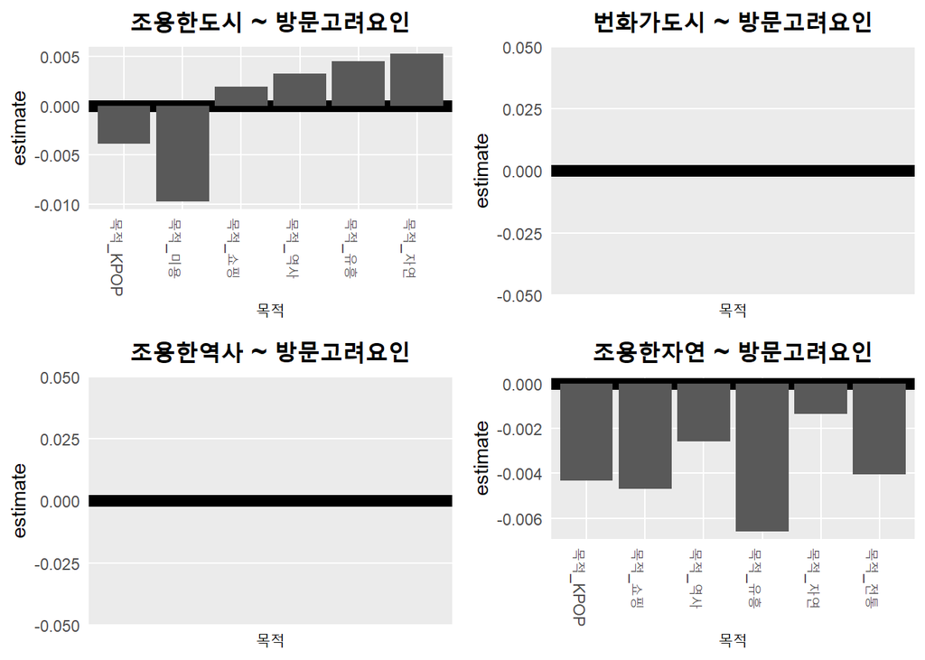

```r
cowplot::plot_grid(g1, g2, g3, g4)
```

# 3 Modeling - Midtro

## 3.1 토픽 ~ 가장 높은 토픽, 방문고려요인, **국적(대만 기준)**

> 방문고려요인을 공변량처럼 생각하여 변수에 다 포함한 다음에 선형회귀를 진행해보자.

```r
for_to_char <- function(fomul){
    paste(as.character(fomul)[2], as.character(fomul)[1], as.character(fomul)[3])
}

test2_model1 <- paste(for_to_char(test1_model1), '+ 국적 * highest_topic')
test2_model2 <- paste(for_to_char(test1_model2), '+ 국적 * highest_topic')
test2_model3 <- paste(for_to_char(test1_model3), '+ 국적 * highest_topic')
test2_model4 <- paste(for_to_char(test1_model4), '+ 국적 * highest_topic')

test2_model1 <- as.formula(test2_model1)
test2_model2 <- as.formula(test2_model2)
test2_model3 <- as.formula(test2_model3)
test2_model4 <- as.formula(test2_model4)


model1_2 <- eval(expr(lm(!!test2_model1, data=df)))
model2_2 <- eval(expr(lm(!!test2_model2, data=df)))
model3_2 <- eval(expr(lm(!!test2_model3, data=df)))
model4_2 <- eval(expr(lm(!!test2_model4, data=df)))
```

```r
significant12 <- broom::tidy(model1_2) %>%
    filter(abs(statistic) > 1.9) # 유의한 것 중에


cond1 <- nchar(significant12$term) < 10 # 교호텀 아닌 것 중에에
cond2 <- grepl('국적', significant12$term) # 국적이 있는가?

g1 <- significant12[cond1&cond2, ] %>%
    ggplot(aes(factor(term,
                      levels=significant12[cond1&cond2, ] %>%
                                    select(term, estimate) %>%
                                    arrange(estimate) %>%
                                    pull(term)
                      ), estimate)) +
    geom_hline(yintercept = 0, size=3) +
    geom_bar(stat='identity') +
    labs(x='국적', title='조용한도시 ~ 국적') +
    theme(plot.title = element_text(face = "bold", size = 15, hjust=0.5),
          axis.ticks = element_blank(),
          axis.text.x = element_text(angle = -90, vjust = 1, hjust = 0),
          panel.grid.minor = element_blank())
```

```r
significant22 <- broom::tidy(model2_2) %>%
    filter(abs(statistic) > 1.9) # 유의한 것 중에


cond1 <- nchar(significant22$term) < 10 # 교호텀 아닌 것 중에에
cond2 <- grepl('국적', significant22$term) # 국적이 있는가?


g2 <- significant22[cond1&cond2, ] %>%
    ggplot(aes(factor(term,
                      levels=significant22[cond1&cond2, ] %>%
                                    select(term, estimate) %>%
                                    arrange(estimate) %>%
                                    pull(term)
                      ), estimate)) +
    geom_hline(yintercept = 0, size=3) +
    geom_bar(stat='identity') +
    labs(x='국적', title='번화가도시 ~ 국적') +
    theme(plot.title = element_text(face = "bold", size = 15, hjust=0.5),
          axis.ticks = element_blank(),
          axis.text.x = element_text(angle = -90, vjust = 1, hjust = 0),
          panel.grid.minor = element_blank())
```

```r
significant32 <- broom::tidy(model3_2) %>%
    filter(abs(statistic) > 1.9) # 유의한 것 중에


cond1 <- nchar(significant32$term) < 10 # 교호텀 아닌 것 중에에
cond2 <- grepl('국적', significant32$term) # 국적이 있는가?


g3 <- significant32[cond1&cond2, ] %>%
    ggplot(aes(factor(term,
                      levels=significant32[cond1&cond2, ] %>%
                                    select(term, estimate) %>%
                                    arrange(estimate) %>%
                                    pull(term)
                      ), estimate)) +
    geom_hline(yintercept = 0, size=3) +
    geom_bar(stat='identity') +
    labs(x='국적', title='조용한역사 ~ 국적') +
    theme(plot.title = element_text(face = "bold", size = 15, hjust=0.5),
          axis.ticks = element_blank(),
          axis.text.x = element_text(angle = -90, vjust = 1, hjust = 0),
          panel.grid.minor = element_blank())
```

```r
significant42 <- broom::tidy(model4_2) %>%
    filter(abs(statistic) > 1.9) # 유의한 것 중에


cond1 <- nchar(significant42$term) < 10 # 교호텀 아닌 것 중에에
cond2 <- grepl('국적', significant42$term) # 국적이 있는가?

g4 <- significant42[cond1&cond2, ] %>%
    ggplot(aes(factor(term,
                      levels=significant42[cond1&cond2, ] %>%
                                    select(term, estimate) %>%
                                    arrange(estimate) %>%
                                    pull(term)
                      ), estimate)) +
    geom_hline(yintercept = 0, size=3) +
    geom_bar(stat='identity') +
    labs(x='국적', title='조용한자연 ~ 국적') +
    theme(plot.title = element_text(face = "bold", size = 15, hjust=0.5),
          axis.ticks = element_blank(),
          axis.text.x = element_text(angle = -90, vjust = 1, hjust = 0),
          panel.grid.minor = element_blank())
```

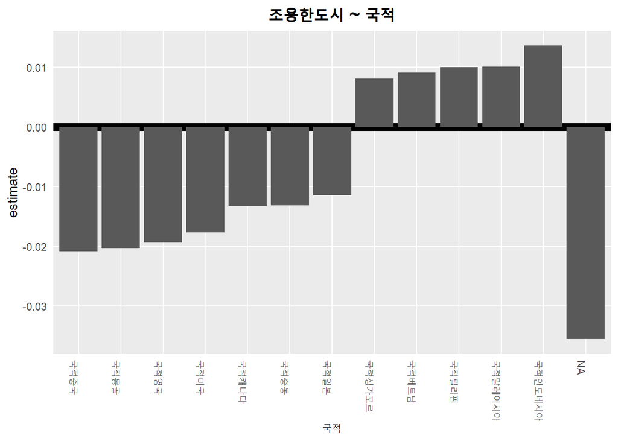

```r
g1
```

국적 변수는 유의한 편이고 **동남아 국적**의 경우 **(도시 - 조용한)**을 선호한다.

[figure not shown]

```r
g2
```

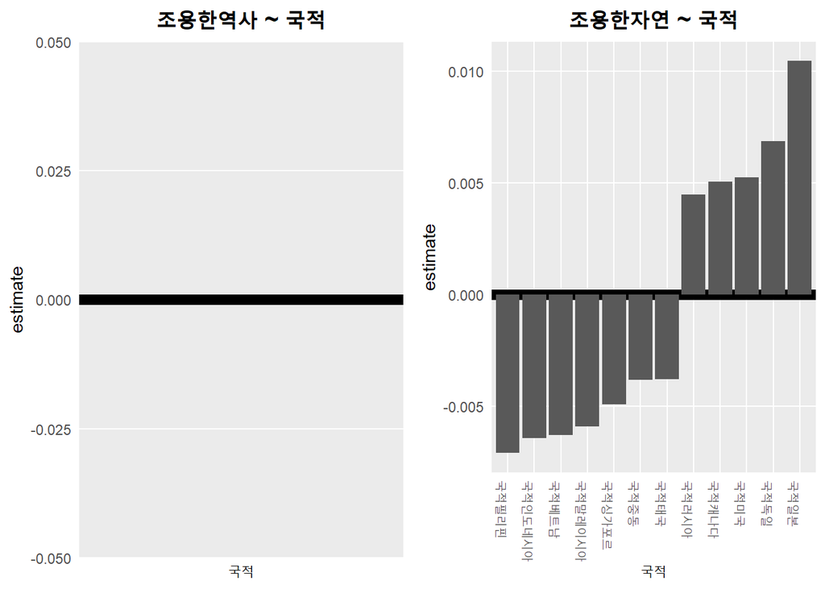

```r
cowplot::plot_grid(g3, g4)
```

국적 변수는 유의한 편이고 **일본과 서양 국가들**이 **조용한 자연**를 선호하는 편이다.

## 3.2 토픽 ~ 가장 높은 토픽, 방문고려요인, 국적, **성별(남성 기준)**

> 방문고려요인, 국적을 공변량처럼 생각하여 변수에 다 포함한 다음에 선형회귀를 진행해보자.

```r
test3_model1 <- paste(for_to_char(test2_model1), '+ 성별 * highest_topic')
test3_model2 <- paste(for_to_char(test2_model2), '+ 성별 * highest_topic')
test3_model3 <- paste(for_to_char(test2_model3), '+ 성별 * highest_topic')
test3_model4 <- paste(for_to_char(test2_model4), '+ 성별 * highest_topic')

test3_model1 <- as.formula(test3_model1)
test3_model2 <- as.formula(test3_model2)
test3_model3 <- as.formula(test3_model3)
test3_model4 <- as.formula(test3_model4)


model1_3 <- eval(expr(lm(!!test3_model1, data=df)))
model2_3 <- eval(expr(lm(!!test3_model2, data=df)))
model3_3 <- eval(expr(lm(!!test3_model3, data=df)))
model4_3 <- eval(expr(lm(!!test3_model4, data=df)))
```

```r
significant <- broom::tidy(model1_3) %>%
    filter(abs(statistic) > 1.9) # 유의한 것 중에


cond1 <- nchar(significant$term) < 10 # 교호텀 아닌 것 중에에
cond2 <- grepl('성별', significant$term) # 국적이 있는가?

g1 <- significant[cond1&cond2, ] %>%
    ggplot(aes(factor(term,
                      levels=significant[cond1&cond2, ] %>%
                                    select(term, estimate) %>%
                                    arrange(estimate) %>%
                                    pull(term)
                      ), estimate)) +
    geom_hline(yintercept = 0, size=3) +
    geom_bar(stat='identity') +
    labs(x='성별', title='조용한도시 ~ 성별') +
    scale_x_discrete(expand = c(0.5,0.5)) +
    theme(plot.title = element_text(face = "bold", size = 15, hjust=0.5),
          axis.ticks = element_blank(),
          axis.text.x = element_text(angle = -30, vjust = 1, hjust = 0),
          panel.grid.minor = element_blank())
```

```r
significant <- broom::tidy(model2_3) %>%
    filter(abs(statistic) > 1.9) # 유의한 것 중에


cond1 <- nchar(significant$term) < 10 # 교호텀 아닌 것 중에에
cond2 <- grepl('성별', significant$term) # 국적이 있는가?
drop_condition <- nrow(significant[cond1 & cond2, ])==0


g2 <- significant[cond1&cond2, ] %>%
    ggplot(aes(factor(term,
                      levels=significant[cond1&cond2, ] %>%
                                    select(term, estimate) %>%
                                    arrange(estimate) %>%
                                    pull(term)
                      ), estimate)) +
    geom_hline(yintercept = 0, size=3) +
    geom_bar(stat='identity') +
    labs(x='목적', title='번화가도시 ~ 성별') +
    scale_x_discrete(expand = c(0.5,0.5)) +
    theme(plot.title = element_text(face = "bold", size = 15, hjust=0.5),
          axis.ticks = element_blank(),
          axis.text.x = element_text(angle = -30, vjust = 1, hjust = 0),
          panel.grid.minor = element_blank())
```

```r
significant <- broom::tidy(model3_3) %>%
    filter(abs(statistic) > 1.9) # 유의한 것 중에


cond1 <- nchar(significant$term) < 10 # 교호텀 아닌 것 중에에
cond2 <- grepl('성별', significant$term) # 국적이 있는가?

g3 <- significant[cond1&cond2, ] %>%
    ggplot(aes(factor(term,
                      levels=significant[cond1&cond2, ] %>%
                                    select(term, estimate) %>%
                                    arrange(estimate) %>%
                                    pull(term)
                      ), estimate)) +
    geom_hline(yintercept = 0, size=3) +
    geom_bar(stat='identity') +
    labs(x='성별', title='조용한역사 ~ 성별') +
    scale_x_discrete(expand = c(0.5,0.5)) +
    theme(plot.title = element_text(face = "bold", size = 15, hjust=0.5),
          axis.ticks = element_blank(),
          axis.text.x = element_text(angle = -30, vjust = 1, hjust = 0),
          panel.grid.minor = element_blank())
```

```r
significant <- broom::tidy(model4_3) %>%
    filter(abs(statistic) > 1.9) # 유의한 것 중에


cond1 <- nchar(significant$term) < 10 # 교호텀 아닌 것 중에에
cond2 <- grepl('성별', significant$term) # 국적이 있는가?

g4 <- significant[cond1&cond2, ] %>%
    ggplot(aes(factor(term,
                      levels=significant[cond1&cond2, ] %>%
                                    select(term, estimate) %>%
                                    arrange(estimate) %>%
                                    pull(term)
                      ), estimate)) +
    geom_hline(yintercept = 0, size=3) +
    geom_bar(stat='identity') +
    labs(x='성별', title='조용한자연 ~ 성별') +
    scale_x_discrete(expand = c(0.5,0.5)) +
    theme(plot.title = element_text(face = "bold", size = 15, hjust=0.5),
          axis.ticks = element_blank(),
          axis.text.x = element_text(angle = -30, vjust = 1, hjust = 0),
          panel.grid.minor = element_blank())
```

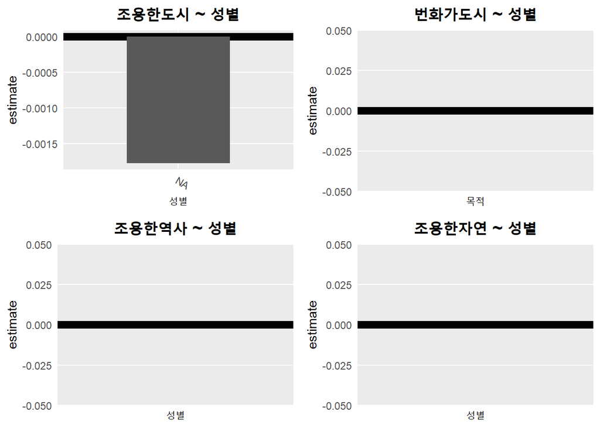

```r
cowplot::plot_grid(g1, g2, g3, g4)
```

성별 변수는 유의한 편이고 **남성**이 **조용한 도시**를 선호하는 편이다.

## 3.3 토픽 ~ 가장 높은 토픽, 방문고려요인, 국적, 성별, **나이(10대 기준)**

> 방문목적, 성별, 국적을 공변량처럼 생각하여 변수에 다 포함한 다음에 선형회귀를 진행해보자.

```r
test4_model1 <- paste(for_to_char(test3_model1), '+ 나이 * highest_topic')
test4_model2 <- paste(for_to_char(test3_model2), '+ 나이 * highest_topic')
test4_model3 <- paste(for_to_char(test3_model3), '+ 나이 * highest_topic')
test4_model4 <- paste(for_to_char(test3_model4), '+ 나이 * highest_topic')

test4_model1 <- as.formula(test4_model1)
test4_model2 <- as.formula(test4_model2)
test4_model3 <- as.formula(test4_model3)
test4_model4 <- as.formula(test4_model4)


model1_4 <- eval(expr(lm(!!test4_model1, data=df)))
model2_4 <- eval(expr(lm(!!test4_model2, data=df)))
model3_4 <- eval(expr(lm(!!test4_model3, data=df)))
model4_4 <- eval(expr(lm(!!test4_model4, data=df)))
```

```r
significant <- broom::tidy(model1_4) %>%
    filter(abs(statistic) > 1.9) # 유의한 것 중에


cond1 <- nchar(significant$term) < 10 # 교호텀 아닌 것 중에에
cond2 <- grepl('나이', significant$term) # 국적이 있는가?

g1 <- significant[cond1&cond2, ] %>%
    ggplot(aes(factor(term,
                      levels=significant[cond1&cond2, ] %>%
                                    select(term, estimate) %>%
                                    arrange(estimate) %>%
                                    pull(term)
                      ), estimate)) +
    geom_hline(yintercept = 0, size=3) +
    geom_bar(stat='identity') +
    labs(x='연령', title='조용한 도시 ~ 연령') +
    scale_x_discrete(expand = c(0.5,0.5)) +
    theme(plot.title = element_text(face = "bold", size = 15, hjust=0.5),
          axis.ticks = element_blank(),
          axis.text.x = element_text(angle = -30, vjust = 1, hjust = 0),
          panel.grid.minor = element_blank())
```

```r
significant <- broom::tidy(model2_4) %>%
    filter(abs(statistic) > 1.9) # 유의한 것 중에


cond1 <- nchar(significant$term) < 10 # 교호텀 아닌 것 중에에
cond2 <- grepl('나이', significant$term) # 국적이 있는가?

g2 <- significant[cond1&cond2, ] %>%
    ggplot(aes(factor(term,
                      levels=significant[cond1&cond2, ] %>%
                                    select(term, estimate) %>%
                                    arrange(estimate) %>%
                                    pull(term)
                      ), estimate)) +
    geom_hline(yintercept = 0, size=3) +
    geom_bar(stat='identity') +
    labs(x='연령', title='번화가도시 ~ 연령') +
    scale_x_discrete(expand = c(0.5,0.5)) +
    theme(plot.title = element_text(face = "bold", size = 15, hjust=0.5),
          axis.ticks = element_blank(),
          axis.text.x = element_text(angle = -30, vjust = 1, hjust = 0),
          panel.grid.minor = element_blank())
```

```r
significant <- broom::tidy(model3_4) %>%
    filter(abs(statistic) > 1.9) # 유의한 것 중에


cond1 <- nchar(significant$term) < 10 # 교호텀 아닌 것 중에에
cond2 <- grepl('나이', significant$term) # 국적이 있는가?



g3 <- significant[cond1&cond2, ] %>%
    ggplot(aes(factor(term,
                      levels=significant[cond1&cond2, ] %>%
                                    select(term, estimate) %>%
                                    arrange(estimate) %>%
                                    pull(term)
                      ), estimate)) +
    geom_hline(yintercept = 0, size=3) +
    geom_bar(stat='identity') +
    labs(x='연령', title='조용한역사 ~ 연령') +
    scale_x_discrete(expand = c(0.5,0.5)) +
    theme(plot.title = element_text(face = "bold", size = 15, hjust=0.5),
          axis.ticks = element_blank(),
          axis.text.x = element_text(angle = -30, vjust = 1, hjust = 0),
          panel.grid.minor = element_blank())
```

```r
significant <- broom::tidy(model4_4) %>%
    filter(abs(statistic) > 1.9) # 유의한 것 중에


cond1 <- nchar(significant$term) < 10 # 교호텀 아닌 것 중에에
cond2 <- grepl('나이', significant$term) # 국적이 있는가?

g4 <- significant[cond1&cond2, ] %>%
    ggplot(aes(factor(term,
                      levels=significant[cond1&cond2, ] %>%
                                    select(term, estimate) %>%
                                    arrange(estimate) %>%
                                    pull(term)
                      ), estimate)) +
    geom_hline(yintercept = 0, size=3) +
    geom_bar(stat='identity') +
    labs(x='연령', title='조용한자연 ~ 연령') +
    scale_x_discrete(expand = c(0.5,0.5)) +
    theme(plot.title = element_text(face = "bold", size = 15, hjust=0.5),
          axis.ticks = element_blank(),
          axis.text.x = element_text(angle = -30, vjust = 1, hjust = 0),
          panel.grid.minor = element_blank())
```

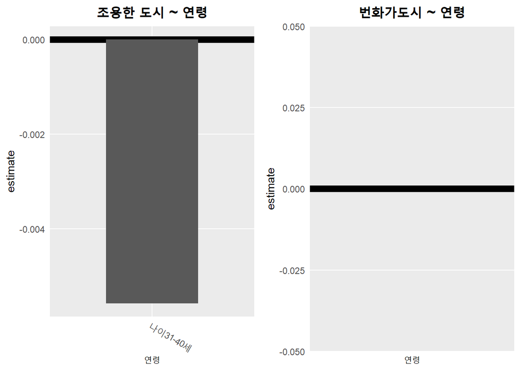

```r
cowplot::plot_grid(g1, g2)
```

연령 변수는 유의한 편이고 **30대**가 **조용한 도시**를 선호하지 않는 편이다.

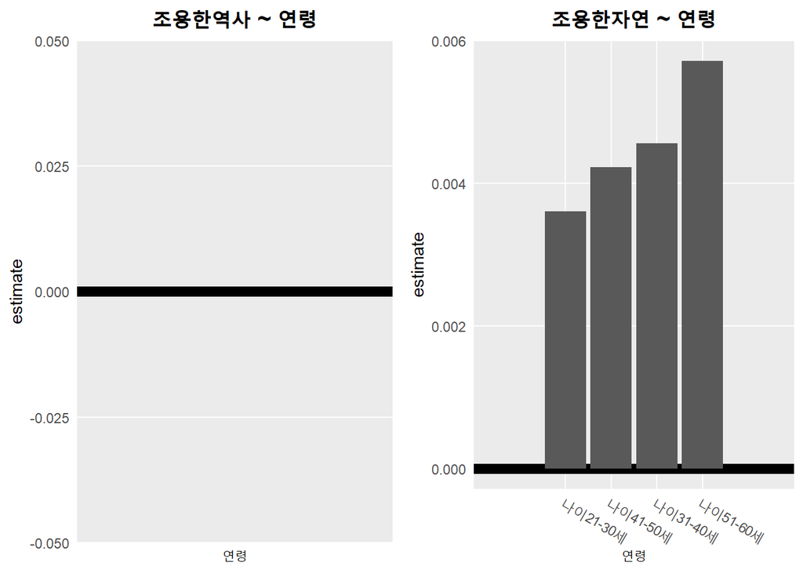

```r
cowplot::plot_grid(g3, g4)
```

## 3.4 Summary

가장 높은 토픽(1, 2, 3, 4)이 무엇인 지 아는 상황에서 만든 회귀모형은 굉장히 높은 설명력을 갖추게 된다.

```r
rbind(broom::glance(model1_4), broom::glance(model2_4), broom::glance(model3_4), broom::glance(model4_4)) %>% mutate(Topic=c('Topic1', 'Topic2', 'Topic3', 'Topic4')) %>%
    select(Topic, adj.r.squared, df)
```

```
## # A tibble: 4 x 3
##   Topic  adj.r.squared    df
##   <chr>          <dbl> <int>
## 1 Topic1         0.998   135
## 2 Topic2         0.987   135
## 3 Topic3         0.977   135
## 4 Topic4         0.997   135
```

# 4 Modeling - ourtro

> prediction from a rank-deficient fit may be misleading

라는 에러가 뜨므로 직접 predict를 해야한다.

```r
X1 <- model.matrix(test4_model1, data=df)
X2 <- model.matrix(test4_model2, data=df)
X3 <- model.matrix(test4_model3, data=df)
X4 <- model.matrix(test4_model4, data=df)

# 인도인 중에 토픽4를 방문한 사람이 없다.
model1_4$coefficients['highest_topic4:국적인도'] = 0
model2_4$coefficients['highest_topic4:국적인도'] = 0
model3_4$coefficients['highest_topic4:국적인도'] = 0
model4_4$coefficients['highest_topic4:국적인도'] = 0


yhat1 <- X1 %*% model1_4$coefficients
yhat2 <- X2 %*% model2_4$coefficients
yhat3 <- X3 %*% model3_4$coefficients
yhat4 <- X4 %*% model4_4$coefficients

estimated_df <- data.frame(topic1 = yhat1, topic2 = yhat2, topic3 = yhat3, topic4 = yhat4)
```

```r
SST1 = sum((df$topic1 - mean(df$topic1))^2)
SSE1 = sum((df$topic1 - yhat1)^2)
print(paste('토픽1의 결정계수 :', (SST1 - SSE1) / SST1))
```

```
## [1] "토픽1의 결정계수 : 0.99759096745033"
```

```r
SST2 = sum((df$topic2 - mean(df$topic2))^2)
SSE2 = sum((df$topic2 - yhat2)^2)
print(paste('토픽2의 결정계수 :', (SST2 - SSE2) / SST2))
```

```
## [1] "토픽2의 결정계수 : 0.987262264870438"
```

```r
SST3 = sum((df$topic3 - mean(df$topic3))^2)
SSE3 = sum((df$topic3 - yhat3)^2)
print(paste('토픽3의 결정계수 :', (SST3 - SSE3) / SST3))
```

```
## [1] "토픽3의 결정계수 : 0.977449698525751"
```

```r
SST4 = sum((df$topic4 - mean(df$topic4))^2)
SSE4 = sum((df$topic4 - yhat4)^2)
print(paste('토픽4의 결정계수 :', (SST4 - SSE4) / SST4))
```

```
## [1] "토픽4의 결정계수 : 0.99678078681844"
```

# 5 파이프라인

```r
lda_results2 <- read.csv('LDA_results2.csv') %>% select(-X)
```

이제 파이프 라인을 생각해보자.

일단 방문 고려요인, 인구통계정보, 관심 주제가 들어온다.

그 다음 예측된 토픽에서 최근접 3개의 여행지를 추천한다.

목적은 한번에 여러개 받지 말고 하나씩 나눠서 받도록 하자!

```r
input <- list()
input[['목적']] <- c('전통')
# '목적_역사','목적_K-POP','목적_자연','목적_미용','목적_전통','목적_패션','목적_쇼핑','목적_유흥'
# character

input[['국적']] <- factor('미국',
                        levels= c("대만", "독일", "러시아", "말레이시아",
                                  "몽골", "미국", "베트남", "싱가포르", "영국",
                                  "인도", "인도네시아", "일본", "중국", "중동",
                                  "캐나다", "태국",  "프랑스", "필리핀", "호주", "홍콩"))
# "대만" "독일""러시아" "말레이시아" "몽골" "미국" "베트남" "싱가포르" "영국"       "인도"       "인도네시아" "일본" "중국" "중동" "캐나다""태국""프랑스" "필리핀" "호주" "홍콩"
# factor

input[['성별']] <- factor('남성', levels = c('남성', '여성'))
# 남성, 여성
# factor

input[['나이']] <- factor('15-20세',levels=c("15-20세", "21-30세", "31-40세", "41-50세", "51-60세", "61세이상"))
# "15-20세", "21-30세", "31-40세", "41-50세", "51-60세", "61세이상"
# factor

input[['highest_topic']] <- factor(2, levels = c(1,2,3,4))
# 1 2 3 4
# factor
```

```r
input_df <- data.frame(목적_역사 = ifelse(any(input$목적 %in% '역사'), 1, 0),
                    목적_KPOP = ifelse(any(input$목적 %in% 'POP'), 1, 0),
                    목적_자연 = ifelse(any(input$목적 %in% '자연'), 1, 0),
                    목적_미용 = ifelse(any(input$목적 %in% '미용'), 1, 0),
                    목적_전통 = ifelse(any(input$목적 %in% '전통'), 1, 0),
                    목적_패션 = ifelse(any(input$목적 %in% '패션'), 1, 0),
                    목적_쇼핑 = ifelse(any(input$목적 %in% '쇼핑'), 1, 0),
                    목적_유흥 = ifelse(any(input$목적 %in% '유흥'), 1, 0),
                    국적 = input$국적,
                    나이 = input$나이,
                    성별 = input[['성별']],
                    highest_topic=input$highest_topic,
                    topic1=0, # 실제론 안들어감
                    topic2=0,
                    topic3=0,
                    topic4=0)
```

```r
X1 <- model.matrix(test4_model1, data=input_df)
X2 <- model.matrix(test4_model2, data=input_df)
X3 <- model.matrix(test4_model3, data=input_df)
X4 <- model.matrix(test4_model4, data=input_df)

# 인도인 중에 토픽4를 방문한 사람이 없다.
model1_4$coefficients['highest_topic4:국적인도'] = 0
model2_4$coefficients['highest_topic4:국적인도'] = 0
model3_4$coefficients['highest_topic4:국적인도'] = 0
model4_4$coefficients['highest_topic4:국적인도'] = 0


yhat1 <- X1 %*% model1_4$coefficients
yhat2 <- X2 %*% model2_4$coefficients
yhat3 <- X3 %*% model3_4$coefficients
yhat4 <- X4 %*% model4_4$coefficients

estimated_df <- data.frame(topic1 = yhat1, topic2 = yhat2, topic3 = yhat3, topic4 = yhat4)
```

```r
result <- data.frame(topic1 =yhat1, topic2 = yhat2,
                     topic3 = yhat3, topic4 = yhat4)

eucl <- function(vector){
    sum(vector^2)
}

topic_location <- lda_results2 %>% select(topic1, topic2, topic3, topic4)

# Three attractions will be recommended
recoomend3 <- order(apply(topic_location - as.numeric(result), 1, eucl)) <= 3
recommend <- lda_results2[recoomend3,c('attraction')]
```

```r
write.csv(recommend, 'Three_recommendation.csv')
```